# s03 — reference-allele bias at heterozygous sites (chr19)

gwct

10/28/2026 11:45 EDT

```r
knitr::opts_chunk$set(echo = TRUE, warning = FALSE, message = FALSE, fig.align = "center")
library(ggplot2); library(dplyr); library(tidyr); library(readr); library(knitr)
source("analyses/lib/design.r")   # bartheme(), corecol(); knit from the project root
```

**Provenance**

- **Rendered from commit** `ff9caa48f3d6` (branch `mason2-sims`) on 2026-10-28 11:45
- **This notebook:** notebook as committed
- **Analysis code:** no uncommitted edits under `analyses/`
- Each data file’s producing script and command: the section’s `MANIFEST.yaml`

# 1 Question & design

**Reference bias is, at bottom, a heterozygous-site phenomenon.** At a het site the individual carries one reference and one alternate allele, so the *truth* is a 50/50 allele balance. But an alt-bearing read carries one extra mismatch to the reference — the alt allele itself — and against an already-divergent background that extra mismatch can tip a *marginal* read below the placement threshold, so it fails to align at the site (lost, mismapped, or clipped over the variant). The alt allele is then absent from the pileup and the balance tips toward reference; severe cases drop the alt entirely and the het is miscalled as homozygous reference (**allelic dropout**). This is the *canonical* signature of reference bias, and it is measured on the **mapping**, independent of which caller runs downstream.

The operative word is *marginal*: it is **exclusion, not degradation**. Splitting the reads at each het site by the base they carry (diagnostic in `analyses/lib/`), the fraction of alt reads *missing* from the pileup grows with divergence (≈ 2 % at D=0 → 13 % at D=0.10), while the alt reads that do survive are unremarkable — equal-or-slightly-*higher* MAPQ than their ref-bearing mates, equal soft-clip rate. The bias lives in the alt reads that vanish, not in degraded copies of the ones we see.

We quantify it with the **reference-allele fraction**

$$\mathrm{RAF} =
\frac{\text{ref-supporting reads}}{\text{ref-supporting reads} +
\text{alt-supporting reads}}$$

counted directly from the pileup at every *true* het SNP site (`pysam count_coverage`, MAPQ ≥ 20, BAQ ≥ 13). Unbiased mapping gives **RAF = 0.5**; reference bias gives **RAF > 0.5**.

**Design.** No new simulations — this reuses the **existing s01 and s02 BAMs** and asks the RAF question at their het sites (`analyses/lib/allele_balance.py`, driven by `het_allele_balance.smk`).

```r
res <- "analyses/s03-heterozygosity/results/"
# --- truth check (Methods): stop rather than score het sites the reads do not carry ---
for (f in c("analyses/s01-baseline-iterative/results/effective-truth/phantom-by-divergence.csv",
            "analyses/s02-indels/results/effective-truth/phantom-by-divergence.csv")) {
  tc <- read_csv(f, col_types = cols())
  stopifnot(sum(tc$n_phantom_het) == 0)
}
lv  <- c("gatk", "bcftools", "freebayes")

load_ab <- function(tag) {
  read_csv(paste0(res, "s03-", tag, "-allele-balance-summary.csv")) %>%
    rename(div = divergence) %>%
    mutate(source = tag, caller = factor(caller, levels = lv), iteration = factor(iteration))
}   # D=0 KEPT: RAF at zero divergence is the unbiased baseline (~0.5)
ab01 <- load_ab("s01")
ab02 <- load_ab("s02")

# seed-average within each (source, div, caller, iteration): mean of the per-BAM summaries
ab <- bind_rows(ab01, ab02) %>%
  group_by(source, div, caller, iteration) %>%
  summarize(across(c(mean_raf, frac_ref_biased, frac_alt_dropout, mean_depth,
                     starts_with("raf_b")), mean),
            n_het = mean(n_het), .groups = "drop")

n_iter <- max(as.integer(as.character(ab$iteration)))
icols  <- corecol(pal = "wilke", numcol = n_iter)   # by iteration
ccols  <- corecol(pal = "wilke", numcol = 3)         # by caller
```

# 2 Reference-allele bias and its correction

The headline: at single-shot mapping RAF sits **above 0.5** and grows with divergence; iteration pulls it back toward the 0.5 truth line. s01 (SNP-only) below — each panel is one caller, the dashed line is the unbiased expectation. At each divergence the grey connector spans the three iterations, so its length *is* the iteration effect (the correction toward 0.5).

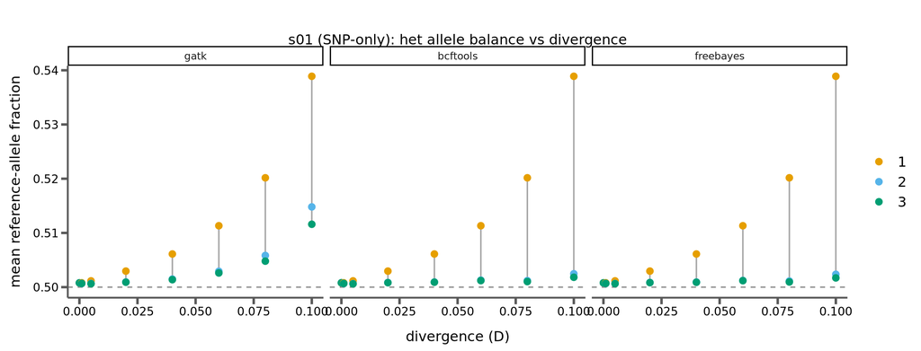

```r
ggplot(filter(ab, source == "s01"),
       aes(x = div, y = mean_raf, color = iteration)) +
  geom_hline(yintercept = 0.5, linetype = "dashed", color = "#888888") +
  geom_line(aes(group = div), color = "grey65", linewidth = 0.6) +
  geom_point(size = 2.4) +
  facet_wrap(~ caller) +
  scale_color_manual(values = icols, name = "iteration") +
  labs(x = "divergence (D)", y = "mean reference-allele fraction",
       title = "s01 (SNP-only): het allele balance vs divergence") +
  bartheme()
```

Single-shot RAF climbs to **≈ 0.54 at D = 0.10**; iteration 3 flattens it back to **≈ 0.50** for the pileup/haplotype callers. The correction is what iterative mapping buys at het sites: by rebuilding the reference toward the sample, alt-bearing reads stop being penalized.

**The residual is caller-dependent.** At D = 0.10, iteration 3 leaves gatk still visibly biased while bcftools/freebayes are essentially unbiased:

```r
ab %>% filter(source == "s01", div == 0.10) %>%
  select(caller, iteration, mean_raf) %>%
  pivot_wider(names_from = iteration, values_from = mean_raf,
              names_prefix = "iter") %>%
  arrange(caller) %>%
  mutate(across(starts_with("iter"), ~ round(.x, 3))) %>%
  kable(caption = "s01 mean RAF at D=0.10 (truth = 0.500)",
        table.attr = 'class="center"')
```

s01 mean RAF at D=0.10 (truth = 0.500)

| caller | iter1 | iter2 | iter3 |
| --- | --- | --- | --- |
| gatk | 0.539 | 0.515 | 0.512 |
| bcftools | 0.539 | 0.502 | 0.502 |
| freebayes | 0.539 | 0.502 | 0.502 |

gatk’s consensus recovers less of the background divergence (its reference-anchored reassembler loses SNPs at high D — see s01), so at iteration 3 its mapping target is still further from the sample, and the residual het bias tracks that shortfall. The allele-balance correction is only as good as the caller’s divergence recovery.

## 2.1 Mechanism: alt-read exclusion, not degraded survivors

Is the bias really *mapping-side loss* of alt reads? Splitting the reads at each true het site by the base they carry (`analyses/lib/altbias_mechanism.py`, no MAPQ filter) answers it directly. The **alt-read deficit** — how far the alt/ref count ratio falls below 1 — is reference bias in its rawest form: the alt allele simply isn’t in the pileup. Solid black is single-shot (iter1, which is caller-independent — all callers share the same mapping); dashed lines are iteration 3 per caller.

```r
mech <- read_csv(paste0(res, "s03-altbias-mechanism.csv")) %>%
  mutate(caller = factor(caller, levels = lv), deficit = 100 * (1 - alt_ref_ratio))
```

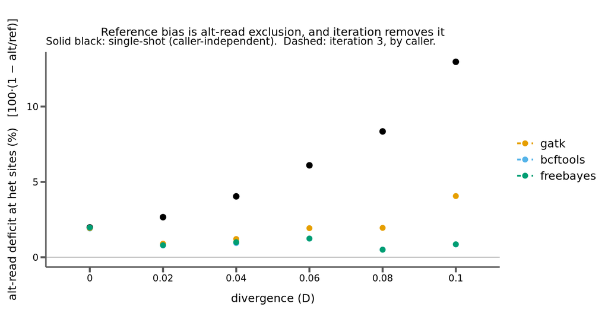

```r
m1 <- filter(mech, iteration == 1); m3 <- filter(mech, iteration == 3)
ggplot() +
  geom_hline(yintercept = 0, color = "#bbbbbb") +
  geom_line(data = m1, aes(factor(divergence), deficit), color = "black", linewidth = 1.1) +
  geom_point(data = m1, aes(factor(divergence), deficit), color = "black", size = 2.6) +
  geom_line(data = m3, aes(factor(divergence), deficit, color = caller), linewidth = 0.9, linetype = "22") +
  geom_point(data = m3, aes(factor(divergence), deficit, color = caller), size = 2.3) +
  scale_color_manual(values = ccols, name = "iter3 caller") +
  labs(x = "divergence (D)", y = "alt-read deficit at het sites (%)   [100·(1 − alt/ref)]",
       title = "Reference bias is alt-read exclusion, and iteration removes it",
       subtitle = "Solid black: single-shot (caller-independent).  Dashed: iteration 3, by caller.") +
  bartheme()
```

```r
mech %>% filter(iteration == 1) %>%
  transmute(divergence,
            `alt-read deficit %` = round(deficit, 1),
            `MAPQ ref` = round(mapq_ref, 1),
            `MAPQ alt (survivors)` = round(mapq_alt, 1)) %>%
  arrange(divergence) %>%
  kable(caption = "Single-shot: the deficit grows with divergence, but surviving alt reads keep normal MAPQ",
        table.attr = 'class="center"')
```

Single-shot: the deficit grows with divergence, but surviving alt reads keep normal MAPQ

| divergence | alt-read deficit % | MAPQ ref | MAPQ alt (survivors) |
| --- | --- | --- | --- |
| 0.00 | 2.0 | 58.6 | 59.4 |
| 0.02 | 2.7 | 58.4 | 59.3 |
| 0.04 | 4.0 | 58.4 | 59.2 |
| 0.06 | 6.1 | 58.3 | 59.1 |
| 0.08 | 8.4 | 58.0 | 59.0 |
| 0.10 | 13.0 | 57.4 | 58.3 |

Two readings. **(1)** Single-shot, the deficit climbs from ≈ 2 % at D = 0 to ≈ 13 % at D = 0.10: the alt allele’s one extra mismatch tips more and more *marginal* reads off the site as the background diverges. **(2)** Iteration 3 collapses it back toward zero for bcftools/freebayes, with gatk lagging — the same caller-limited correction the RAF shows, from the same cause. And the surviving alt reads are **not** degraded: their MAPQ matches (slightly beats) the ref reads at every divergence (table). The bias is *exclusion* — reads that vanish — not *degradation* of the reads we keep.

## 2.2 The distribution, not just the mean

The mean understates it: single-shot mapping doesn’t just nudge RAF up, it grows a shoulder of het sites near RAF = 1 (alt allele barely seen). Below is the full per-site RAF distribution at D = 0.10 for bcftools, iteration 1 vs iteration 3 — the iter-1 mass piled at the right edge is the reference-bias tail, and iteration collapses it back onto 0.5.

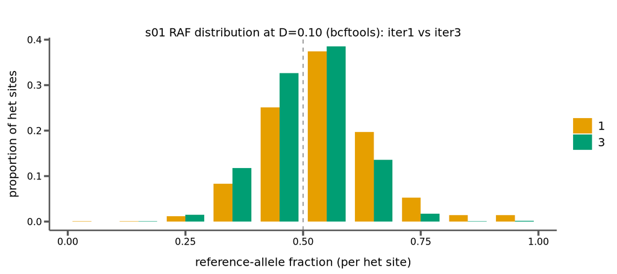

```r
mids <- seq(0.05, 0.95, by = 0.1)
dist <- ab %>% filter(source == "s01", caller == "bcftools", div == 0.10,
                      iteration %in% c("1", "3")) %>%
  select(iteration, starts_with("raf_b")) %>%
  pivot_longer(starts_with("raf_b"), names_to = "bin", values_to = "count") %>%
  mutate(raf = mids[as.integer(sub("raf_b", "", bin)) + 1]) %>%
  group_by(iteration) %>% mutate(prop = count / sum(count)) %>% ungroup()

ggplot(dist, aes(x = raf, y = prop, fill = iteration)) +
  geom_col(position = "dodge", width = 0.08) +
  geom_vline(xintercept = 0.5, linetype = "dashed", color = "#888888") +
  scale_fill_manual(values = icols[c(1, 3)], name = "iteration") +
  labs(x = "reference-allele fraction (per het site)", y = "proportion of het sites",
       title = "s01 RAF distribution at D=0.10 (bcftools): iter1 vs iter3") +
  bartheme()
```

## 2.3 Read fate at het sites: where the excluded alt reads go

The deficit above is a *count* — alt vs ref reads in the pileup. This resolves it to the individual read: for every read whose mason-truth span covers a het site, what does it do at the site’s reference base `p` — present the alt, present the ref, get soft-clipped over `p`, map elsewhere, or not map at all? It is the project’s standard read-fate analysis (`analyses/lib/variant_read_fate.py --het --aggregate`, `run_vrf_aggregate.sh`, whole chromosome, on the s01 SNP-only data so coordinates are identity across iterations). Because mason puts the alt on one **phased** haplotype, `n_true_alt` (via the `oH` tag) is the ~half of covering reads that truly carry the alt; `f_alt` is the fraction of *those* that align the alt at `p` — the surviving alt support. **“Called” here means the caller called the site correctly as a het (GT 0/1)** at that iteration; a het miscalled as hom-ref (alt lost) or hom-alt is *not* called.

```r
library(ggalluvial); library(patchwork)
AGG <- paste0(res, "vrf-agg")
rdcsv <- function(pat) bind_rows(lapply(list.files(AGG, pat, full.names = TRUE), read_csv, col_types = cols()))
h3     <- rdcsv("hcomp.csv$") %>% mutate(caller = factor(caller, levels = lv))
gtraj3 <- rdcsv("gtraj.csv$")
```

### 2.3.1 The allele balance, restored (read resolution)

`RAF@p` = ref-presenting / (ref- + alt-presenting) reads at `p` — the reference-allele fraction built from what actually aligns at the base (0.5 = unbiased). It reproduces the pileup RAF from the read side and shows iteration pulling it back to 0.5.

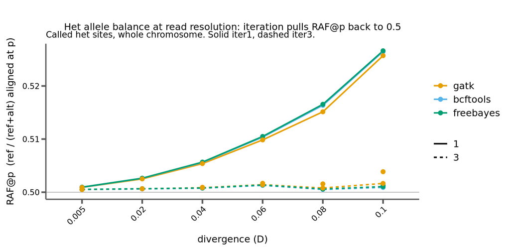

```r
bal <- h3 %>% filter(status == "called") %>% mutate(rafp = ref_at_p / (ref_at_p + alt_at_p))
ggplot(bal, aes(factor(divergence), rafp, color = caller, linetype = factor(iteration),
                group = interaction(caller, iteration))) +
  scale_x_discrete(guide = guide_axis(angle = 45)) +
  geom_hline(yintercept = 0.5, color = "#bbbbbb") +
  geom_line(linewidth = 0.9) + geom_point(size = 2.3) +
  scale_color_manual(values = ccols, name = "caller") +
  scale_linetype_manual(values = c(`1` = "solid", `3` = "22"), name = "iteration") +
  labs(x = "divergence (D)", y = "RAF@p  (ref / (ref+alt) aligned at p)",
       title = "Het allele balance at read resolution: iteration pulls RAF@p back to 0.5",
       subtitle = "Called het sites, whole chromosome. Solid iter1, dashed iter3.") + bartheme()
```

### 2.3.2 Where do the lost alt reads go?

Composition of covering reads at `p`, split by whether the site is called correctly as a het. The excluded alt reads surface here as **clipped-over-p / mapped-elsewhere / unmapped**, not as ref bases.

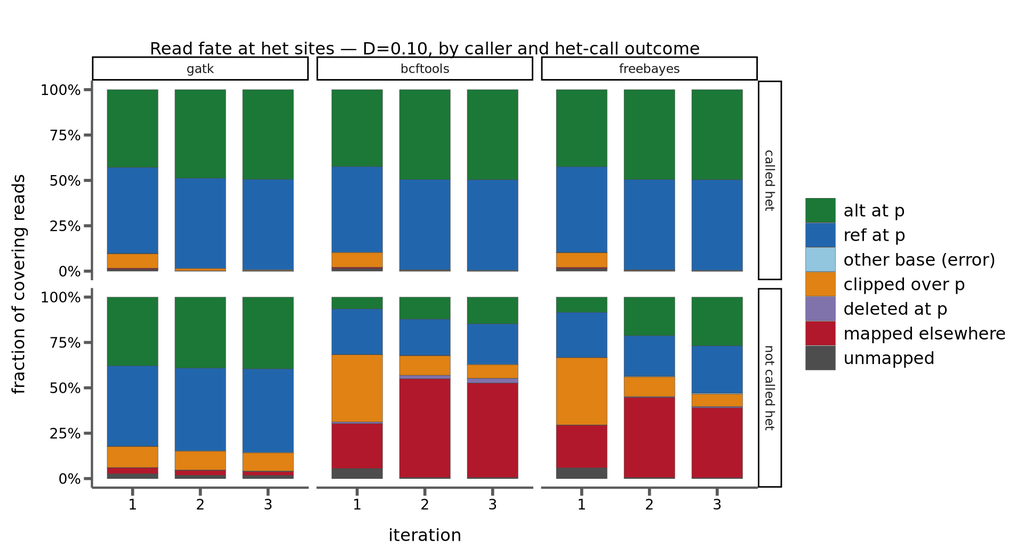

```r
cats <- c("alt_at_p", "ref_at_p", "err_at_p", "clipped", "deleted", "mapped_elsewhere", "unmapped")
nice <- c(alt_at_p = "alt at p", ref_at_p = "ref at p", err_at_p = "other base (error)",
          clipped = "clipped over p", deleted = "deleted at p", mapped_elsewhere = "mapped elsewhere", unmapped = "unmapped")
fcol <- setNames(c("#1b7837", "#2166ac", "#92c5de", "#e08214", "#8073ac", "#b2182b", "#4d4d4d"), unname(nice[cats]))
h3 %>% filter(divergence == 0.10) %>%
  pivot_longer(all_of(cats), names_to = "atp", values_to = "reads") %>%
  mutate(frac = reads / n_reads, atp = factor(nice[atp], levels = unname(nice[cats])),
         status = recode(status, called = "called het", not_called = "not called het")) %>%
  ggplot(aes(factor(iteration), frac, fill = atp)) + geom_col(width = 0.75, color = "grey30", linewidth = 0.12) +
  facet_grid(status ~ caller) + scale_fill_manual(values = fcol, name = "what is at position p") +
  scale_y_continuous(labels = scales::percent) +
  labs(x = "iteration", y = "fraction of covering reads", title = "Read fate at het sites — D=0.10, by caller and het-call outcome") +
  bartheme()
```

**Interpretation.** For *called* het sites the balance is near 50/50 alt/ref with little loss, and iteration trims the residual clipping to near zero (restoring RAF@p to 0.5). *Not-called* het sites are the mechanism: their alt support is depressed and the missing reads appear as **clipped / mapped-elsewhere / unmapped** — the alt-haplotype reads are *excluded*, so the pileup looks hom-ref and the het is missed. This is the pileup-level “exclusion, not degradation” result made per-read, and it shows dropout is **alignment-limited** (reads not placed at `p`), which is why iteration — which re-anchors those reads — recovers het calls.

### 2.3.3 Joint state: alt-support survival vs het call (G)

Per het site, its (called-as-het?, `f_alt` bin) trajectory across the three iterations. Lower box = called het, upper = not called; colour = `f_alt` (alt-support survival) bin. Low-`f_alt` sites (alt reads lost) sit in the not-called box and climb into called as iteration restores their alt reads.

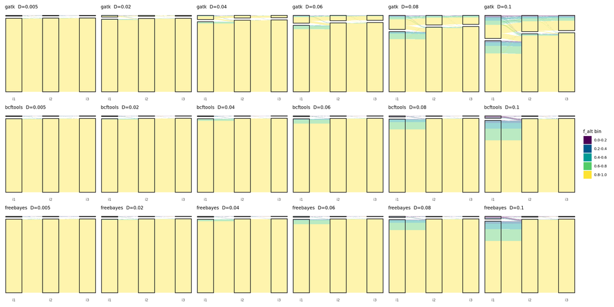

```r
BIN   <- c("0.0-0.2", "0.2-0.4", "0.4-0.6", "0.6-0.8", "0.8-1.0")
fbcol <- setNames(hcl.colors(5, "Viridis"), BIN)
Glev  <- c(paste("not called", BIN, sep = " · "), "gap", paste("called", BIN, sep = " · "))
makeG <- function(cc, dd) {
  g <- gtraj3 %>% filter(caller == cc, divergence == dd, fb1 %in% BIN, fb2 %in% BIN, fb3 %in% BIN)
  lodes <- g %>% mutate(id = row_number()) %>%
    pivot_longer(c(s1, fb1, s2, fb2, s3, fb3), names_to = c(".value", "iter"), names_pattern = "([a-z]+)([0-9])") %>%
    transmute(id, n = n_snps, iter, status = ifelse(s == "not_called", "not called", "called"),
              fb = factor(fb, levels = BIN), state = factor(paste(status, fb, sep = " · "), levels = Glev), is_gap = FALSE)
  gapN <- round(0.03 * sum(g$n_snps))
  lodes <- bind_rows(lodes, tibble(id = max(lodes$id) + 1, n = gapN, iter = c("1", "2", "3"), status = "gap",
                     fb = factor(NA, levels = BIN), state = factor("gap", levels = Glev), is_gap = TRUE))
  box <- lodes %>% filter(!is_gap) %>% group_by(iter, status) %>% summarize(n = sum(n), .groups = "drop") %>%
    group_by(iter) %>% mutate(ncall = sum(n[status == "called"])) %>% ungroup() %>%
    mutate(pos = as.integer(iter), xmin = pos - 0.22, xmax = pos + 0.22,
           ymin = ifelse(status == "called", 0, ncall + gapN), ymax = ifelse(status == "called", ncall, ncall + gapN + n))
  ggplot(lodes, aes(x = iter, stratum = state, alluvium = id, y = n, fill = fb, alpha = is_gap)) +
    geom_flow() +
    geom_rect(data = box, aes(xmin = xmin, xmax = xmax, ymin = ymin, ymax = ymax), inherit.aes = FALSE, fill = "white") +
    geom_stratum(color = NA, width = 0.44) +
    geom_rect(data = box, aes(xmin = xmin, xmax = xmax, ymin = ymin, ymax = ymax), inherit.aes = FALSE, fill = NA, color = "grey15", linewidth = 0.6) +
    scale_alpha_manual(values = c(`FALSE` = 0.4, `TRUE` = 0), guide = "none") +
    scale_fill_manual(values = fbcol, name = "f_alt bin", na.value = "white", na.translate = FALSE) +
    scale_x_discrete(labels = c("i1", "i2", "i3"), expand = c(0.08, 0.08)) +
    labs(x = NULL, y = NULL, title = sprintf("%s  D=%s", cc, format(dd))) +
    theme_minimal(base_size = 9) + theme(panel.grid = element_blank(), axis.text.y = element_blank(), plot.title = element_text(size = 9))
}
conds <- expand.grid(dd = c(0.005, 0.02, 0.04, 0.06, 0.08, 0.10), cc = lv, stringsAsFactors = FALSE)
patchwork::wrap_plots(Map(makeG, conds$cc, conds$dd), ncol = 6, guides = "collect")
```

**Data dictionary** — `results/vrf-agg/vrf-agg-<caller>-<div>-{gtraj,hcomp}.csv`. `hcomp`: per (iteration × het-call status) the summed counts, over all het sites, of covering reads by what is at `p` (`alt_at_p`, `ref_at_p`, `err_at_p`, `clipped`, `deleted`, `mapped_elsewhere`, `unmapped`; plus `n_reads` = all covering, `n_true_alt` context in the tool). `gtraj`: number of het sites (`n_snps`) following each 3-iteration trajectory of (status `s1..s3`, `f_alt` bin `fb1..fb3`). `f_alt` = alt-aligned-at-`p` / alt-haplotype reads (`oH`); status = caller called GT 0/1 at the site.

## 2.4 Companion decomposition: what changes when a het site flips to called?

The s01 companion decomposition, run on the het data (`--het --pileup`): for each het site we join the position-centric pileup at `p` with the mismapped-in/out counts and the **off-`p` neighborhood load** (unrecovered hom-div SNPs within ±200 bp), across the three fates — here **flip = the site becomes correctly called as a het (0/1)**. Two het-specific reading notes: (1) `ref reads at p` are now *real* — the reference haplotype supplies ~half the reads — so the contamination axis to watch is **mismapped-in ref** (foreign reads), not raw `ref_p`; (2) `f_alt` is the alt-haplotype support surviving at `p`. Shared code: `analyses/lib/decomp_figs.R` (+ `run_vrf_pileup.sh`, `run_neighborhood.sh`).

```r
source("analyses/lib/decomp_figs.R")
pairs <- decomp_load("analyses/s03-heterozygosity/results/vrf-pileup",
                     "analyses/s03-heterozygosity/results/neighborhood/neighborhood-per-snp.csv")
```

Per-site **distributions** by fate (boxplots), one figure per divergence:

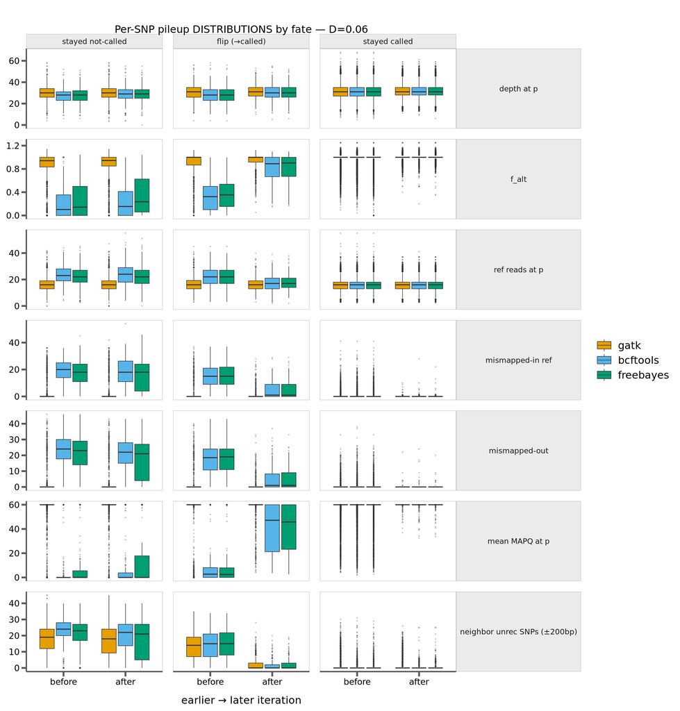

```r
decomp_distfig(pairs, 0.06)
```

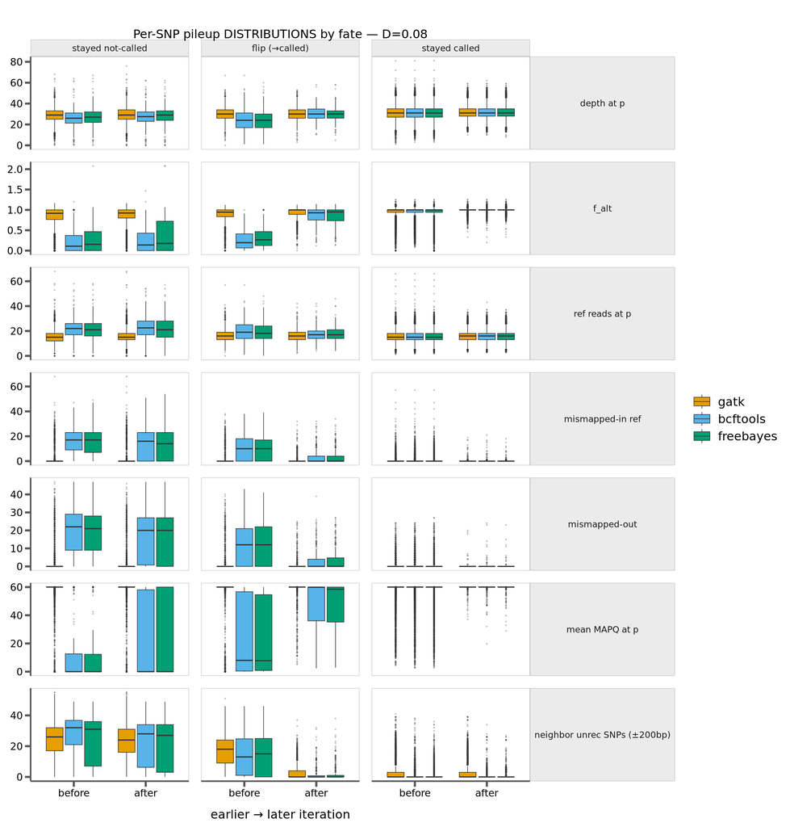

```r
decomp_distfig(pairs, 0.08)
```

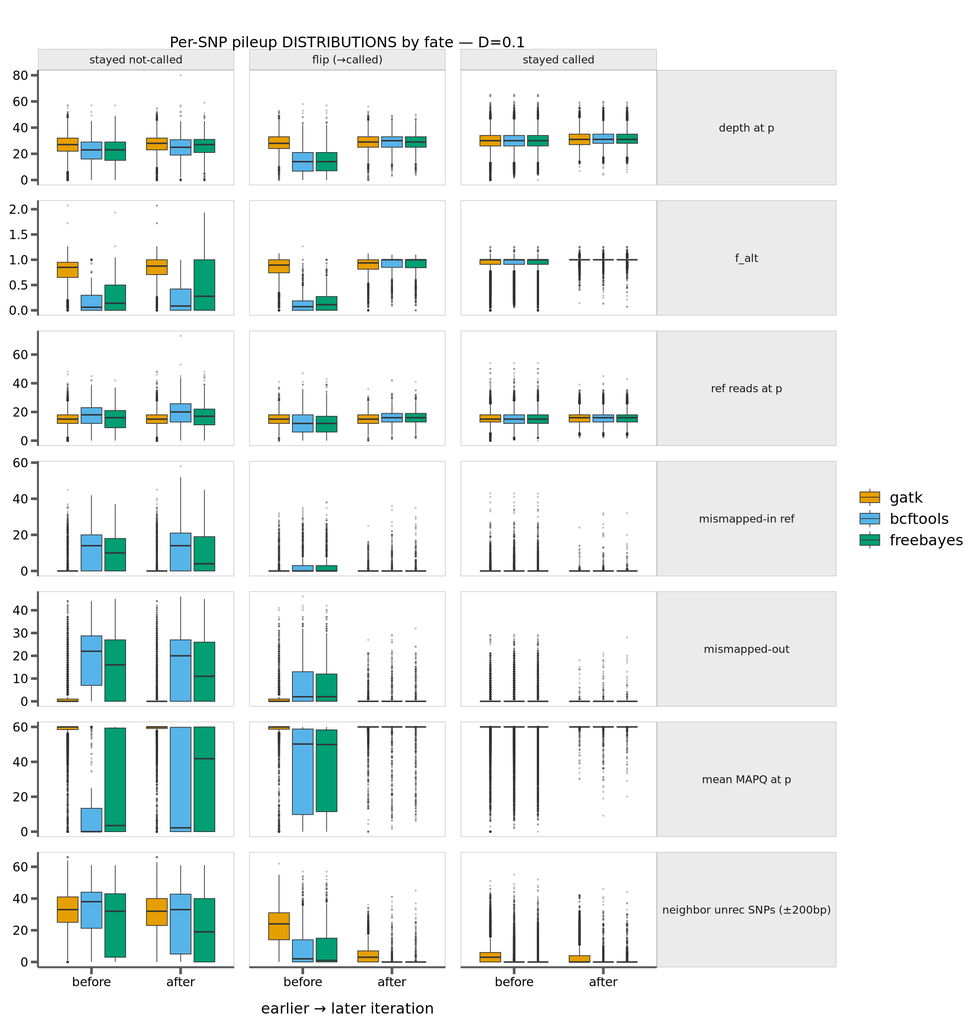

```r
decomp_distfig(pairs, 0.10)
```

**Mean** trend across divergences, one figure per fate:

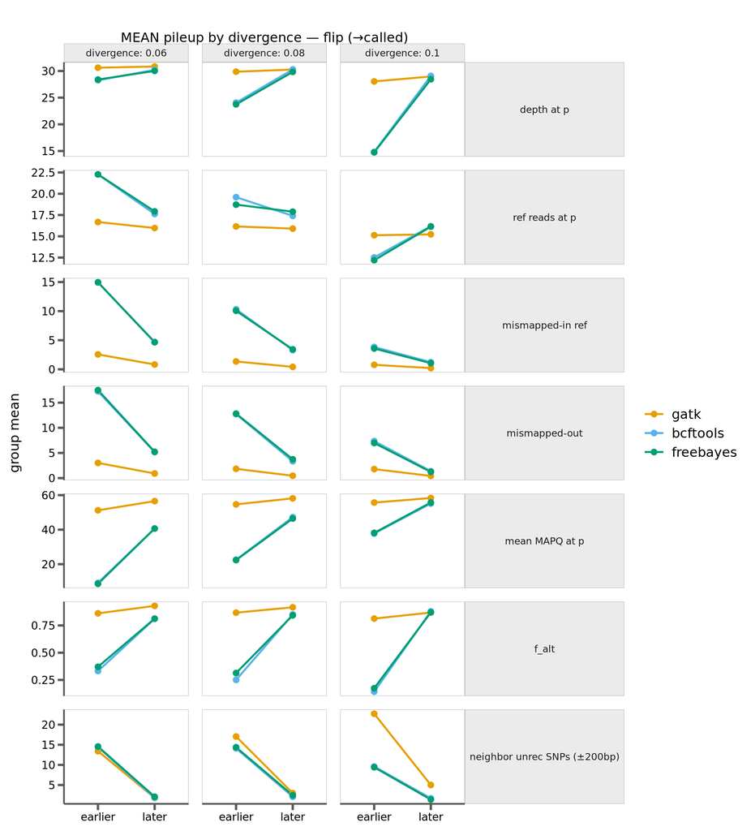

```r
decomp_meantrend(pairs, "flip (→called)")
```

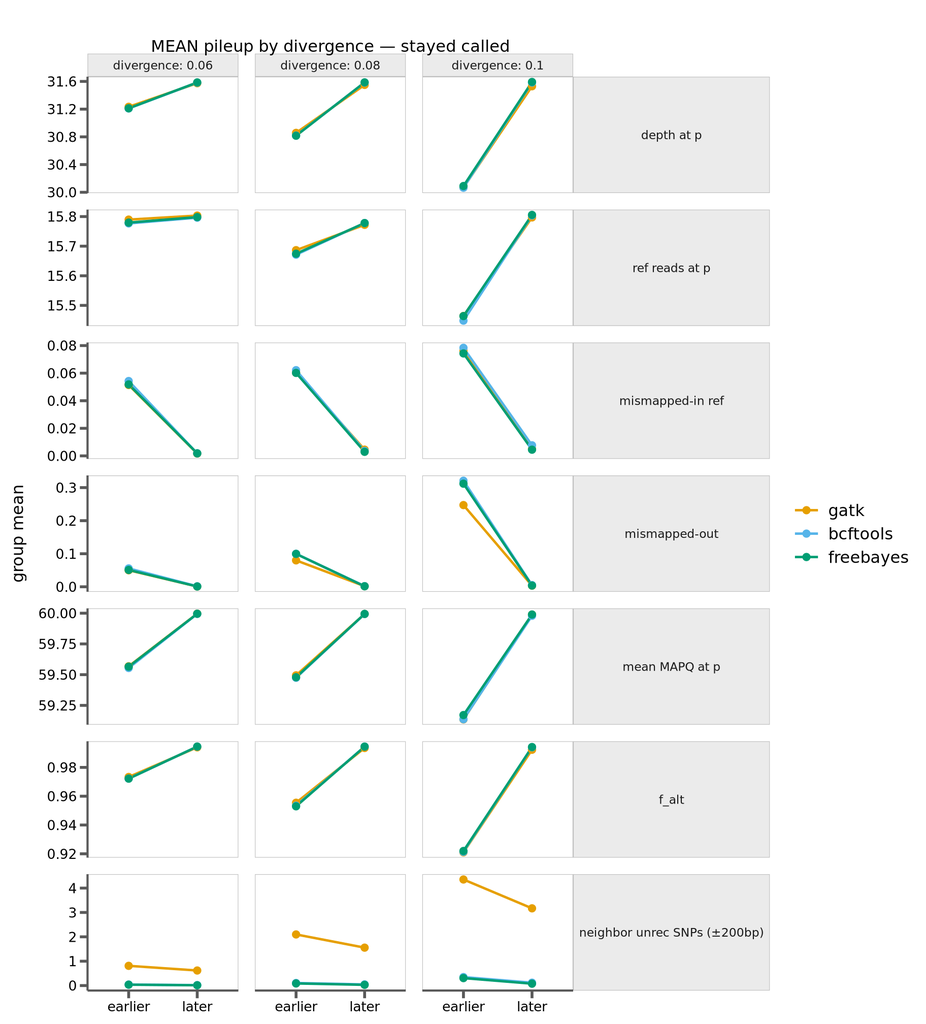

```r
decomp_meantrend(pairs, "stayed called")
```

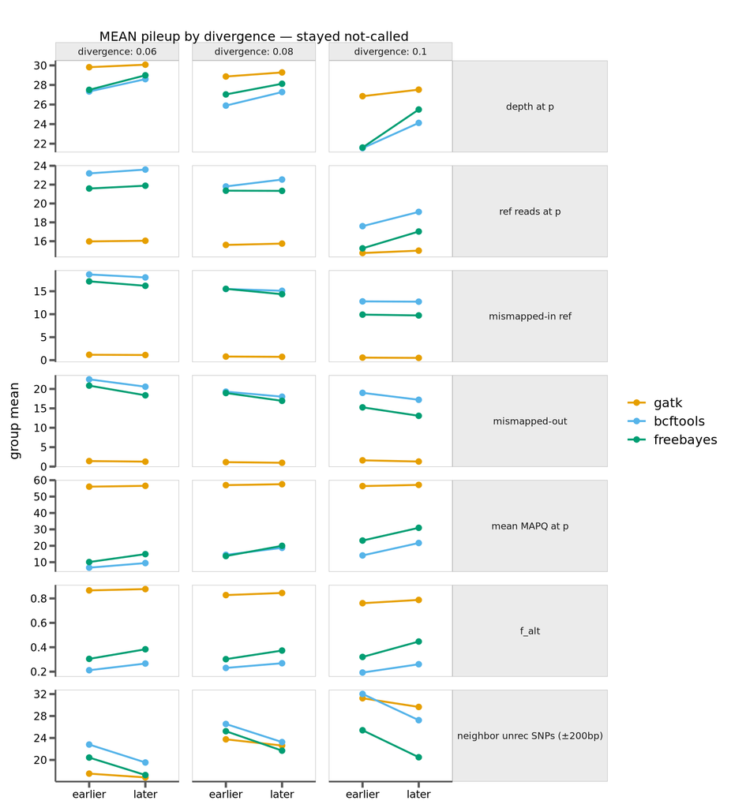

```r
decomp_meantrend(pairs, "stayed not-called")
```

The **gatk signature**, the **assemblable neighborhood**, and the flips by **starting `f_alt` bin**:

```r
kable(decomp_gatksig_clean(pairs, het = TRUE), table.attr = 'class="center"',
      caption = paste("Fraction of flipped het sites whose pileup at p already looked call-ready before",
                      "the flip (D=0.10). Het-aware: 'clean' = high alt-hap support, low mismapped-in ref,",
                      "high MAPQ (ref reads are the real ref haplotype, so not a cleanliness signal)."))
```

Fraction of flipped het sites whose pileup at p already looked call-ready before the flip (D=0.10). Het-aware: ‘clean’ = high alt-hap support, low mismapped-in ref, high MAPQ (ref reads are the real ref haplotype, so not a cleanliness signal).

| caller | n flips | pileup already clean before flip |
| --- | --- | --- |
| gatk | 3512 | 81% |
| bcftools | 808 | 1% |
| freebayes | 867 | 2% |

```r
kable(decomp_gatksig_delta(pairs), table.attr = 'class="center"',
      caption = "Mean absolute change in each pileup axis across the flip (D=0.10).")
```

Mean absolute change in each pileup axis across the flip (D=0.10).

| caller | Δ depth | Δ ref | Δ mismap-in | Δ MAPQ | Δ f_alt |
| --- | --- | --- | --- | --- | --- |
| gatk | 1.4 | 0.7 | 0.6 | 2.8 | 0.06 |
| bcftools | 15.8 | 7.0 | 2.8 | 17.4 | 0.74 |
| freebayes | 15.2 | 6.5 | 2.7 | 17.6 | 0.70 |

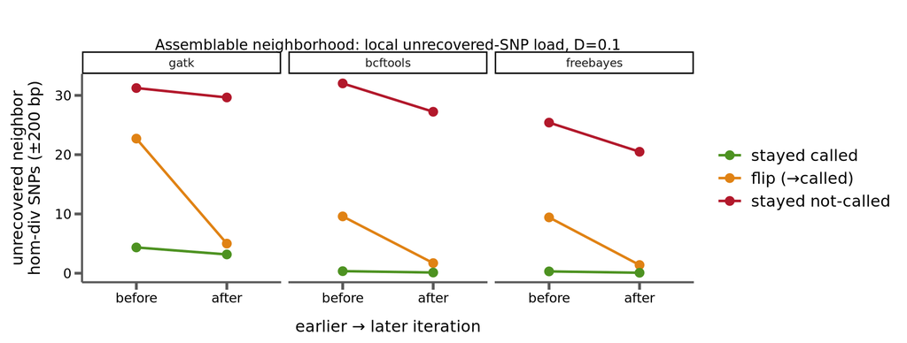

```r
decomp_neighfig("analyses/s03-heterozygosity/results/neighborhood/neighborhood-summary.csv")
```

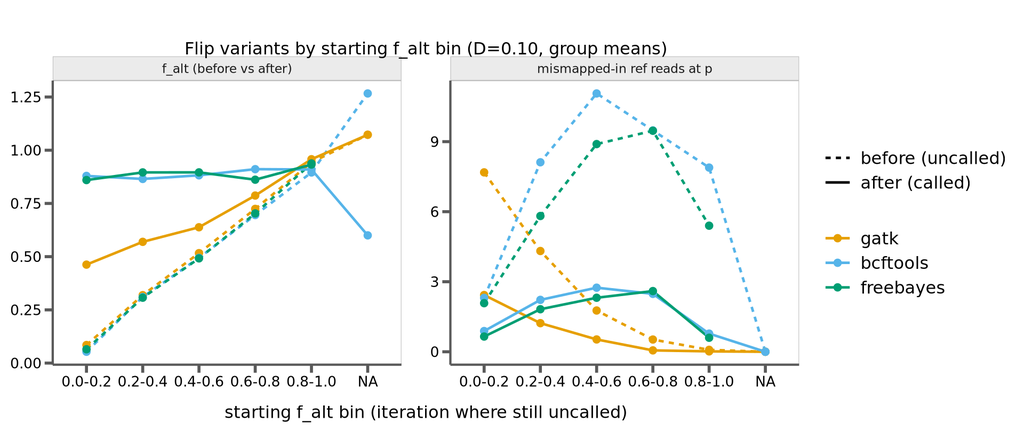

```r
decomp_bybin(pairs)
```

**Interpretation.** The same mechanism carries over to het calling. **gatk** flips happen with the pileup at `p` already call-ready (largest “already clean” fraction, smallest per-axis change) — its off-`p` neighborhood unrecovered-SNP load collapses (≈23→5 at D=0.10) as the consensus converges, so the reference-anchored reassembler can finally resolve the het haplotype; **bcftools/freebayes** flips clear a contaminated pileup — mismapped-in ref reads leave and MAPQ rises — restoring an alt/ref balance the caller will call `0/1`. So het dropout is corrected by iteration through the very same alignment-vs-assembler split as the hom-div SNPs, now measured per het site.

# 3 Do indels worsen het allele bias?

Yes — substantially. A read spanning a nearby unrepresented **indel** maps as badly as (or worse than) one carrying a diverged SNP, so at het sites embedded in indel-rich sequence the alt allele is lost far more often. Comparing single-shot (iteration 1) RAF and dropout, s01 (SNP-only) vs s02 (SNP + indels):

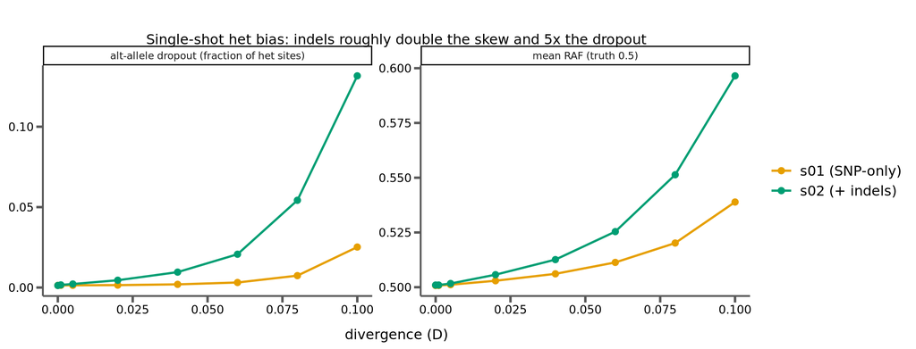

```r
comp <- ab %>% filter(iteration == "1") %>%   # iter1 is caller-independent; take one caller
  filter(caller == "bcftools") %>%
  select(source, div, mean_raf, frac_alt_dropout) %>%
  pivot_longer(c(mean_raf, frac_alt_dropout), names_to = "metric", values_to = "value") %>%
  mutate(metric = recode(metric,
                         mean_raf = "mean RAF (truth 0.5)",
                         frac_alt_dropout = "alt-allele dropout (fraction of het sites)"))

ggplot(comp, aes(x = div, y = value, color = source, group = source)) +
  geom_line(linewidth = 0.9) + geom_point(size = 2.3) +
  facet_wrap(~ metric, scales = "free_y") +
  scale_color_manual(values = ccols[c(1, 3)], name = "dataset",
                     labels = c(s01 = "s01 (SNP-only)", s02 = "s02 (+ indels)")) +
  labs(x = "divergence (D)", y = NULL,
       title = "Single-shot het bias: indels roughly double the skew and 5x the dropout") +
  bartheme()
```

At **D = 0.10**, adding indels lifts single-shot RAF from **0.539 → 0.597** and alt-allele dropout from **2.5 % → 13.2 %**. Iteration still corrects both, but less completely: s02 iteration-3 RAF lands at **0.515** (bcftools) to **0.538** (gatk) versus s01’s **0.502–0.512**, and dropout at **2.4–5.7 %** versus **0.2–0.9 %**. Indels leave a residual het bias that iteration only partly erases — because rebuilding the correct indel is itself the hard, caller-dependent step (see s02).

## 3.1 Allelic dropout across the sweep

Dropout — the fraction of true het sites where the alt allele is missing entirely (a het miscalled homozygous-reference) — is the clinically relevant failure. Both datasets, all iterations:

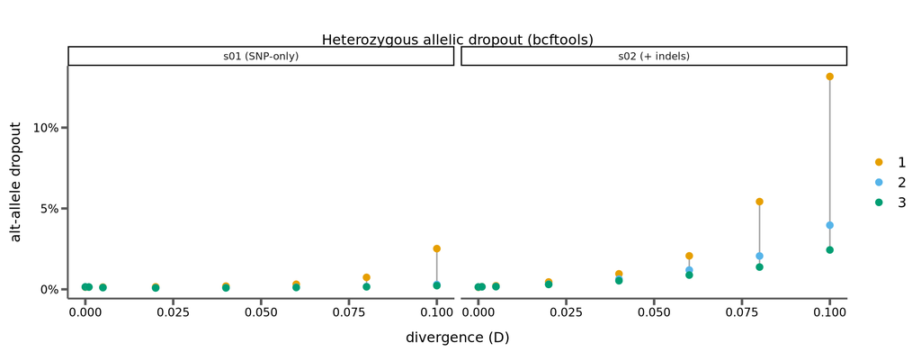

```r
ggplot(filter(ab, caller == "bcftools"),
       aes(x = div, y = frac_alt_dropout, color = iteration)) +
  geom_line(aes(group = div), color = "grey65", linewidth = 0.6) +
  geom_point(size = 2.4) +
  facet_wrap(~ source, labeller = as_labeller(
    c(s01 = "s01 (SNP-only)", s02 = "s02 (+ indels)"))) +
  scale_color_manual(values = icols, name = "iteration") +
  scale_y_continuous(labels = scales::percent) +
  labs(x = "divergence (D)", y = "alt-allele dropout",
       title = "Heterozygous allelic dropout (bcftools)") +
  bartheme()
```

# 4 Does het *density* amplify the bias? (Phase 2)

Everything so far holds het rate fixed at H = 0.005 and varies *divergence*. But is the bias driven by divergence, or does the *density* of het sites amplify it on its own? A denser field of het sites means a single read more often carries **multiple** alt alleles at once, compounding the mapping penalty. Phase 2 tests this directly with a small SNP-only sweep: **H ∈ {0.005, 0.01, 0.02}** at low and high divergence (**D ∈ {0.04, 0.10}**), seed 42, produced by re-running the s01 workflow into `data/s03-hetsweep` (`run_phase2_hetsweep.sh`; H = 0.005 reuses s01).

```r
load_raw <- function(path) read_csv(path) %>%
  rename(div = divergence, het = heterozygosity) %>%
  filter(div %in% c(0.04, 0.10), seed == 42, caller == "bcftools",
         iteration %in% c(1, 3)) %>%
  mutate(iteration = factor(iteration), div = factor(div))

p2 <- bind_rows(
  load_raw(paste0(res, "s03-s01-allele-balance-summary.csv")),        # H=0.005
  load_raw(paste0(res, "s03-hetsweep-0.01-allele-balance-summary.csv")),
  load_raw(paste0(res, "s03-hetsweep-0.02-allele-balance-summary.csv")))
```

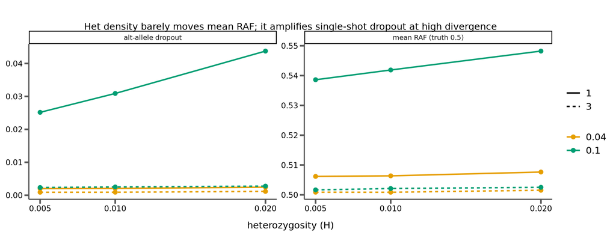

```r
p2l <- p2 %>% select(div, het, iteration, mean_raf, frac_alt_dropout) %>%
  pivot_longer(c(mean_raf, frac_alt_dropout), names_to = "metric", values_to = "value") %>%
  mutate(metric = recode(metric, mean_raf = "mean RAF (truth 0.5)",
                         frac_alt_dropout = "alt-allele dropout"))

ggplot(p2l, aes(x = het, y = value, color = div, linetype = iteration,
                group = interaction(div, iteration))) +
  geom_line(linewidth = 0.9) + geom_point(size = 2.3) +
  facet_wrap(~ metric, scales = "free_y") +
  scale_color_manual(values = ccols[c(1, 3)], name = "divergence") +
  scale_linetype_manual(values = c("1" = "solid", "3" = "22"), name = "iteration") +
  scale_x_continuous(breaks = c(0.005, 0.01, 0.02)) +
  labs(x = "heterozygosity (H)", y = NULL,
       title = "Het density barely moves mean RAF; it amplifies single-shot dropout at high divergence") +
  bartheme()
```

# 5 Summary

- **Reference bias at het sites is real and measurable.** RAF climbs above the 0.5 truth line with divergence (≈ 0.54 at D = 0.10, SNP-only) and grows a tail of near-total alt-allele loss.
- **Iterative mapping corrects it.** Rebuilding the reference toward the sample stops penalizing alt-bearing reads; by iteration 3 RAF returns to ≈ 0.50 for the pileup/haplotype callers.
- **The correction is caller-limited.** gatk’s reference-anchored reassembler recovers less background divergence, so its iteration-3 mapping target is still off and a residual het bias (RAF ≈ 0.51 SNP-only, 0.54 with indels) remains. Het-bias correction tracks divergence recovery.
- **Indels roughly double the single-shot skew and 5× the dropout** (RAF 0.539 → 0.597, dropout 2.5 % → 13.2 % at D = 0.10), and leave a residual that iteration only partly erases — because correctly rebuilding the indel is the hard step.
- **Het density is a second-order effect (Phase 2).** Divergence, not density, drives the bias: quadrupling H (0.005 → 0.02) barely moves mean RAF (≤ 0.009), and only amplifies *single-shot* dropout at high divergence (2.5 % → 4.4 %) — an effect iteration erases completely.

*Caveat:* s02 and the Phase-2 sweep are single seed (42); s01 seed-to-seed variance was < 0.1 pt, so the point estimates should be representative. Replicate seeds and extended iterations are one-line config changes away.